# Geospatial Risk Modeling: Narcotics Crime in Chicago

*Madhura Gurav*

# **Introduction**

[Chicago has a long history of organized crime](https://www.dea.gov/sites/default/files/2018-07/DIR-013-17%20Cartel%20and%20Gangs%20in%20Chicago%20-%20Unclassified.pdf) and it is a well-known fact that a large number of street gangs operate in the area. In addition to the city’s violent crimes issue, there exists high rates of drug abuse and drug related crimes. Drugs are being made easily available by the Mexican Drug Trafficking Organizations (DTOs) to the local gangs, which act as the main distributors in the city. A steady supply of drugs along with a strong demand have facilitated a strong foundation for drug trafficking in Chicago, making it harder for the law enforcement agencies to curb it.

The aim of this project is to predict the risk of occurance of narcotics crimes in Chicago by the means of predictive regression modeling, which utilizes features of past crimes and other environmental factors. The model is also tested to check how well it can generalize to different locations and contexts.

As we look at the results, it is also helpful to keep in mind that crimes are linked to reporting bias and overpolicing based on factors such as race, location, etc. For example, narcotics crimes tend to be highly monitored and reported in low-income or minority-dominated neighborhoods as compared to higher-income neighborhoods. Another thing that may affect the distribution of crimes is the “Borken Windows Theory”. Some neighborhoods have certain environmental risk factors that encourage such activities and result in higher crime rates. Visible signs of crime and negative behavior create an urban environment that encourages further crime. Factors such as abandoned buildings and rundown lots tend to attract more crime. The observed clustering in crime could be due to a higher propensity for the crime to occur in that area, but may also be due to selection bias.

# **Data**

### *A map of Narcotics Possession in Chicago*

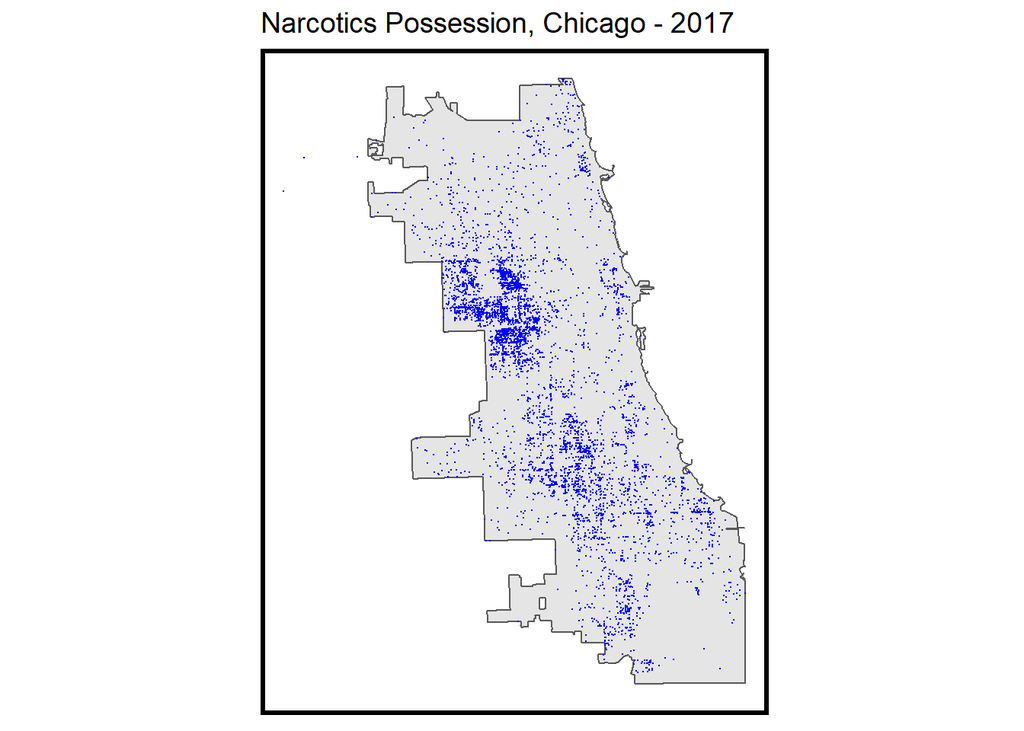

```r
ggplot() +
  geom_sf(data = chicagoBoundary) +
  geom_sf(data = narcotics, colour="blue", size=0.1, show.legend = "point") +
  labs(title= "Narcotics Possession, Chicago - 2017") +
  mapTheme()
```

The narcotics data for 2017 was sourced from the Chicago Open Data website. The above map shows the distribution of narcotics crimes. Based on the map, we can see that the crimes were spread out all over the city but mainly concentrated in ther western and center areas.

### *A map of narcotics possession cases joined to the fishnet*

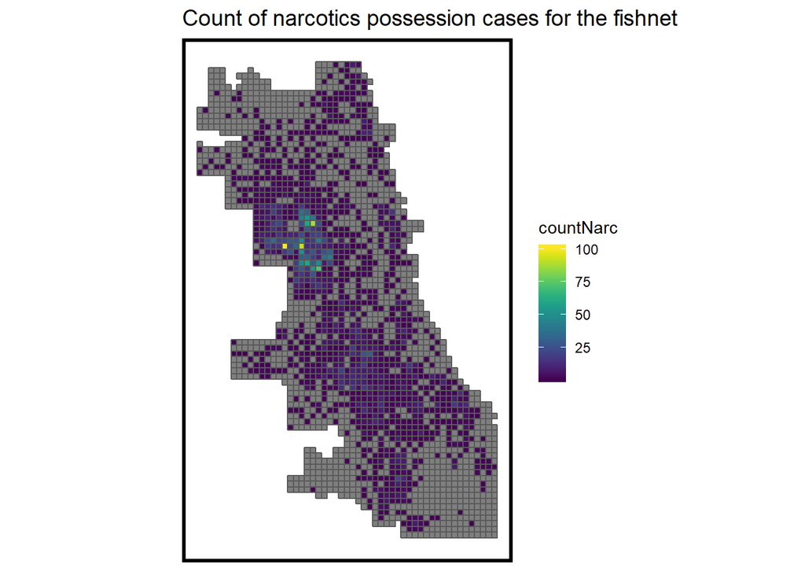

```r
crime_net <-
  narcotics %>%
  dplyr::select() %>%
  mutate(countNarc = 1) %>%
  aggregate(., fishnet, sum) %>%
  mutate(countAssualt = ifelse(is.na(countNarc), 0, countNarc),
         uniqueID = rownames(.),
         cvID = sample(round(nrow(fishnet) / 24), size=nrow(fishnet), replace = TRUE))

#plotting the fishnet
ggplot() +
  geom_sf(data = crime_net, aes(fill = countNarc)) +
  scale_fill_viridis() +
  labs(title = "Count of narcotics possession cases for the fishnet") +
  mapTheme()
```

This map shows the spatial structure of narcotics cases in Chicago and we can observe the hotspots for this crime.

# **Risk Factors**

Environmental risk factors such as abandoned buildings, abandoned cars, liquor retail, sanitation issues, graffiti, street lights out, high risk food inspection cases and distance to green roofs were selected to predict narcotics crime risk in Chicago. These factors were chosen based on the assumption that environmental factors contribute to the ditribution of narcotics crime in Chicago. The data was again obtained from the city’s open data website. These faceted plots below show the distribution of these risk factors within the city.

### *Distribution of the risk factors*

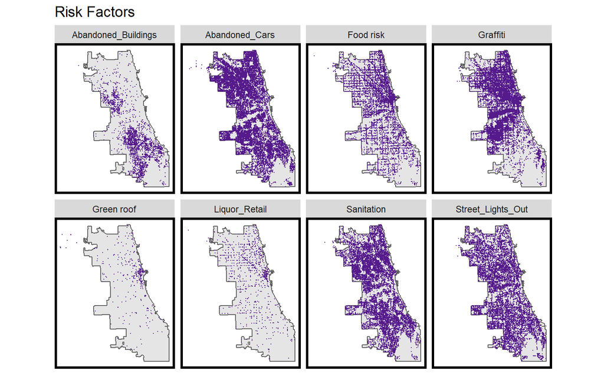

```r
ggplot() +
  geom_sf(data=chicagoBoundary) +
  geom_sf(data = rbind(abandonCars,streetLightsOut,abandonBuildings,
                       liquorRetail, graffiti, sanitation, food, greenRoof),
          size = .1, color="purple4") +
  facet_wrap(~Legend, ncol = 4) +
  labs(title = "Risk Factors") +
  mapTheme()
```

### *Distribution of the risk factors in the fishnet*

The plots below show the count of each risk factor in the grid cells of the Chicago fishnet.

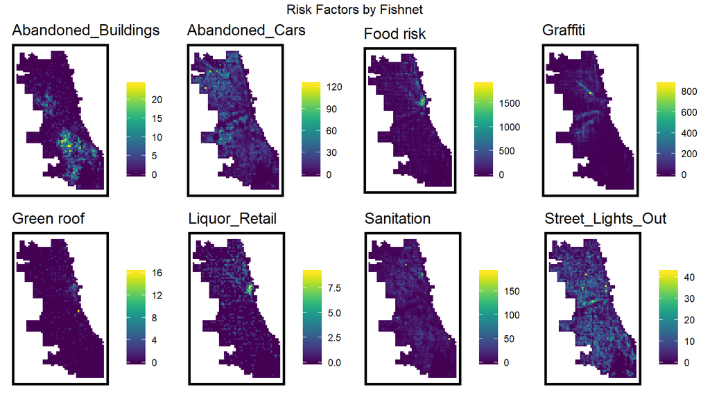

```r
do.call(grid.arrange,c(mapList, ncol =4, top = "Risk Factors by Fishnet"))
```

### *Distance to nearby risk factors*

Although, certain areas or grid cells have a lower count of the risk factors, they may be influenced by surrounding grid cells which have a higher count of these factors and thereby belong to the high risk category. Calcultaing the nearest neighbors of the risk factors controls for such distribution patterns. The faceted plots below demonstrate the distance between each cell to its closest three risk factors.

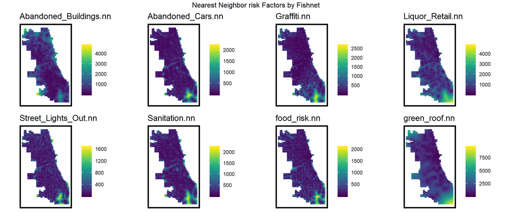

```r
do.call(grid.arrange,c(mapList, ncol =4, top = "Nearest Neighbor risk Factors by Fishnet"))
```

### *Distance to the CBD*

The distance to the loop is visualized the plot below. The loop in Chicago is considered as the downtown area or the CBD.

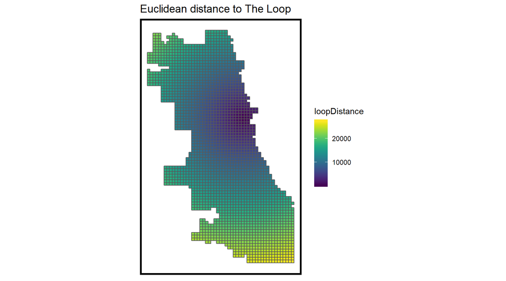

```r
loopPoint <-
  neighborhoods %>%
  filter(name == "Loop") %>%
  st_centroid()

vars_net$loopDistance =
  st_distance(st_centroid(vars_net),loopPoint) %>%
  as.numeric()

ggplot() +
  geom_sf(data=vars_net, aes(fill=loopDistance)) +
  scale_fill_viridis() +
  labs(title="Euclidean distance to The Loop") +
  mapTheme()
```

# **Spatial Structure of Narcotics Crimes**

The local spatial structure of narc is measured using Local Moran’s I metric. It measures the spatial autocorrelation between a location and its neighboring grid cells i.e. whether there is some similarity (correlation) between nearby observations. A spatial weights matrix is used. Here the queen continguity matrix is used which takes into account every neighboring grid cell in the horizontal, vertical and diagonal directions. The plots below show the narcotics count, Local Moran’s I for each grid cell, the p-value of Local Moran’s I for each grid cell, and the significant crime hotspot areas (measured by whether the p-value is less than 0.05). It can be observed that there is clustering of hotspots in the western part of the city and a small cluster near the southern part.

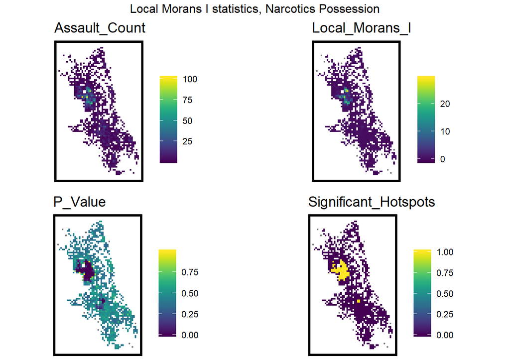

```r
final_net.nb <- poly2nb(final_net, queen=TRUE)
final_net.weights <- nb2listw(final_net.nb, style="W", zero.policy=TRUE)

final_net.localMorans <-
  cbind(
    as.data.frame(localmoran(final_net$countNarc, final_net.weights)),
    as.data.frame(final_net, NULL)) %>%
  st_sf() %>%
  dplyr::select(Assault_Count = countNarc,
                Local_Morans_I = Ii,
                P_Value = `Pr(z > 0)`) %>%
  mutate(Significant_Hotspots = ifelse(P_Value <= 0.05, 1, 0)) %>%
  gather(Variable, Value, -geometry)

vars <- unique(final_net.localMorans$Variable)
varList <- list()

for(i in vars){
  varList[[i]] <-
    ggplot() +
    geom_sf(data = filter(final_net.localMorans, Variable == i), aes(fill = Value), colour=NA) +
    scale_fill_viridis(name="") +
    labs(title=i) +
    mapTheme()}

do.call(grid.arrange,c(varList, ncol = 2, top = "Local Morans I statistics, Narcotics Possession"))
```

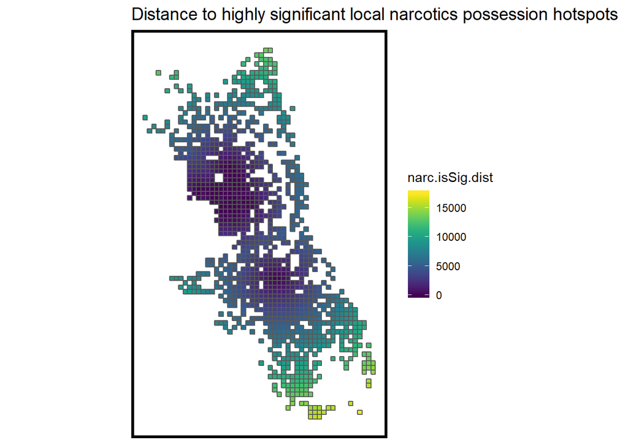

```r
final_net <-
  final_net %>%
  mutate(narc.isSig = ifelse(localmoran(final_net$countNarc,
                                            final_net.weights)[,5] <= 0.0000001, 1, 0)) %>%
  mutate(narc.isSig.dist = nn_function(st_coordinates(st_centroid(final_net)),
                                           st_coordinates(st_centroid(
                                             filter(final_net, narc.isSig == 1))), 1 ))

ggplot() +
  geom_sf(data = final_net, aes(fill = narc.isSig.dist)) +
  scale_fill_viridis() +
  labs(title = "Distance to highly significant local narcotics possession hotspots") +
  mapTheme()
```

# **Correlation scatterplots**

The scatterplots below check whether there is correlation between the risk factors and the dependent variable (countNar). The count of risk factors and the risk factor nearest neighbor features tell similar stories (even though some of the correlated pairs show association in different direction) and thus both features for a given risk factor cannot be included in the model because of co-linearity. These plots help us understand which type of feature for a given risk factor should be included.

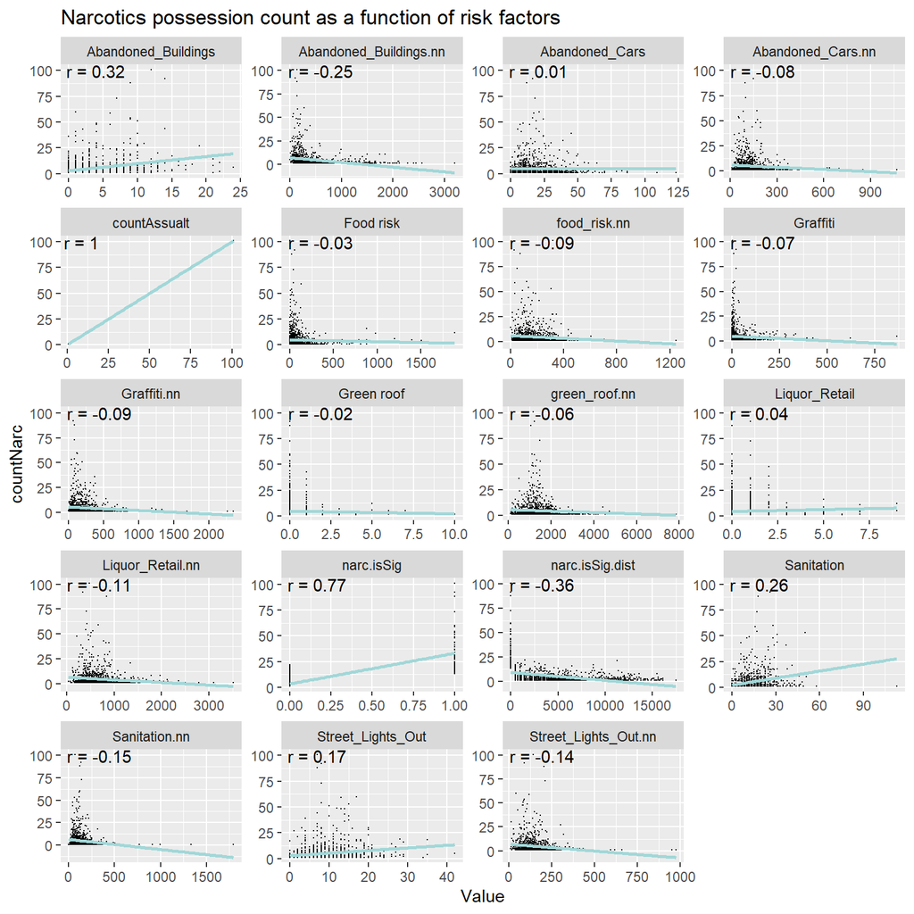

```r
correlation.long <-
  st_set_geometry(final_net, NULL) %>%
  dplyr::select(-uniqueID, -cvID, -loopDistance, -name, -District) %>%
  gather(Variable, Value, -countNarc)

correlation.cor <-
  correlation.long %>%
  group_by(Variable) %>%
  summarize(correlation = cor(Value, countNarc, use = "complete.obs"))

ggplot(correlation.long, aes(Value, countNarc)) +
  geom_point(size = 0.1) +
  geom_text(data = correlation.cor, aes(label = paste("r =", round(correlation, 2))),
            x=-Inf, y=Inf, vjust = 1, hjust = -.1) +
  geom_smooth(method = "lm", se = FALSE, colour = "#a2d7d8") +
  facet_wrap(~Variable, ncol = 4, scales = "free") +
  labs(title = "Narcotics possession count as a function of risk factors")
```

The histogram below shows the distribution of count of Narcotics crimes by grid cell. The histogram shows that many of the grids cells have zero or or very few crime cases and is not normally distributed around the mean. Therefore, linear or OLS regression will not give appropriate results. Poisson Regression is selected as the method for prediction.

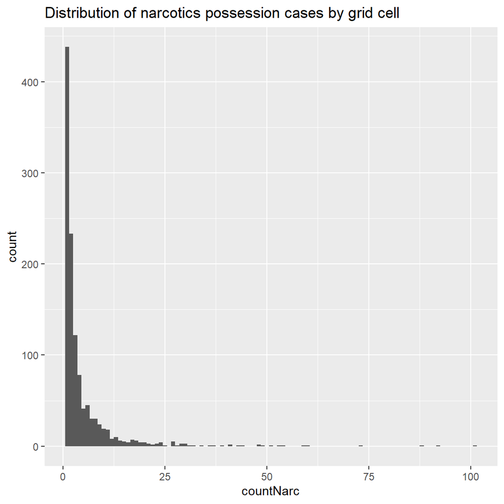

```r
ggplot(final_net, aes(countNarc)) +
  geom_histogram(binwidth = 1) +
  labs(title = "Distribution of narcotics possession cases by grid cell")
```

# **Regression model and Cross validation**

Two types of regression equations are used. The first using the predictor variables *reg.vars* which consist of only the risk factor nearest neighbors, while the second regression uses the predictor variables *reg.ss.vars* which consist of the risk factor nearest neighbors as well as spatial structure variables (narc.isSig and narc.isSig.dist). Both k-fold and LOGO (Leave-one-group-out) cross validations are carried out for both models.

### *Distribution of errors for each of the regression models*

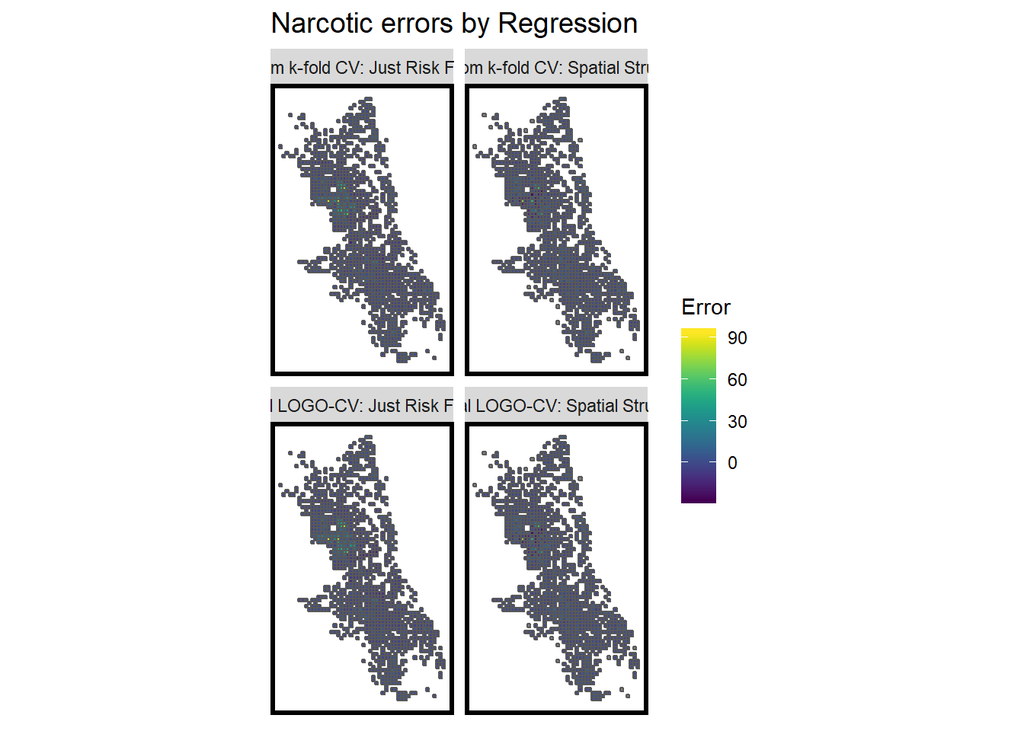

```r
grid.arrange(
  reg.summary %>%
    ggplot() +
    geom_sf(aes(fill = Error)) +
    facet_wrap(~Regression) +
    scale_fill_viridis() +
    labs(title = "Narcotic errors by Regression") +
    mapTheme() + theme())
```

### *Table of MAE and standard deviation MAE by regression*

This table gives the Mean Absolute Error (MAE) and its standard deviation for the different regressions. Based on these metrics it is apparent that the regression models which included the spatial structure perform better.

```r
st_set_geometry(reg.summary, NULL) %>%
  group_by(Regression) %>%
  summarize(MAE = round(mean(abs(Prediction - countNarc), na.rm = T),2),
            SD_MAE = round(sd(abs(Prediction - countNarc), na.rm = T),2)) %>%
  kable(caption = "MAE by regression") %>%
  kable_styling("striped", full_width = F) %>%
  row_spec(2, color = "black", background = "#FDE725FF") %>%
  row_spec(4, color = "black", background = "#FDE725FF")
```

MAE by regression

| Regression | MAE | SD_MAE |
| --- | --- | --- |
| Random k-fold CV: Just Risk Factors | 3.79 | 6.72 |
| Random k-fold CV: Spatial Structure | 2.70 | 4.49 |
| Spatial LOGO-CV: Just Risk Factors | 3.94 | 6.92 |
| Spatial LOGO-CV: Spatial Structure | 2.73 | 4.49 |

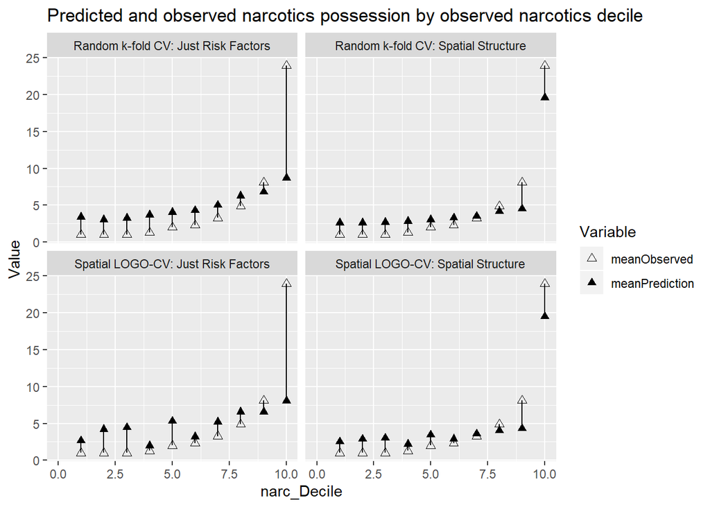

```r
st_set_geometry(reg.summary, NULL) %>%
  group_by(Regression) %>%
  mutate(narc_Decile = ntile(countNarc, 10)) %>%
  group_by(Regression, narc_Decile) %>%
  summarize(meanObserved = mean(countNarc, na.rm=T),
            meanPrediction = mean(Prediction, na.rm=T)) %>%
  gather(Variable, Value, -Regression, -narc_Decile) %>%
  ggplot(aes(narc_Decile, Value, shape = Variable)) +
  geom_point(size = 2) + geom_path(aes(group = narc_Decile), colour = "black") +
  scale_shape_manual(values = c(2, 17)) +
  facet_wrap(~Regression) + xlim(0,10) +
  labs(title = "Predicted and observed narcotics possession by observed narcotics decile")
```

# **Generalizability to race context**

Reporting-bias often takes place in the race context. Therefore, the generalizability of the model to race contexts is tested. The census tracts are split into two groups: Majority_White (where the population of white people is greater than 50%) and Majority_Non_White (where the population of white people is lesser than 50%). The table gives the mean absolute errors (MAE) by race context for each of the four regressions.

```r
final_reg <-
  filter(reg.summary) %>%
  mutate(uniqueID = rownames(.))

final_reg.tracts <-
  st_join(st_centroid(final_reg), tracts17) %>%
  st_set_geometry(NULL) %>%
  left_join(dplyr::select(final_reg, uniqueID)) %>%
  st_sf() %>%
  na.omit()
st_set_geometry(final_reg.tracts, NULL) %>%
  group_by(Regression, raceContext) %>%
  summarize(mean.Error = mean(Error, na.rm = T)) %>%
  spread(raceContext, mean.Error) %>%
  kable(caption = "Mean Error by neighborhood racial context") %>%
  kable_styling("striped", full_width = F)
```

Mean Error by neighborhood racial context

| Regression | Majority_Non_White | Majority_White |
| --- | --- | --- |
| Random k-fold CV: Just Risk Factors | 0.8055788 | -1.4540722 |
| Random k-fold CV: Spatial Structure | 0.2836855 | -0.5272795 |
| Spatial LOGO-CV: Just Risk Factors | 0.9169677 | -1.5662607 |
| Spatial LOGO-CV: Spatial Structure | 0.3538012 | -0.5469452 |

Consistent with the results so far, the models with the spatial features report lower errors and generalize better in the neighborhood racial context. The key takeaway is that the model overpredicts in Majority_Non_White neighborhoods and underpredicts in Majority_White neighborhoods.

# **Map comparing kernel density to risk predictions**

The predicted risk hotspots were compared with the observed hotspots. The maps for observed hotsports were generated using kernel density at 1000 Ft , 1500 Ft, 2000 Ft distances. The value of the kernel density in a particular place is the sum of all the kernels that underlie it. Thus, areas that have many points in close proximity will have the relative densities.

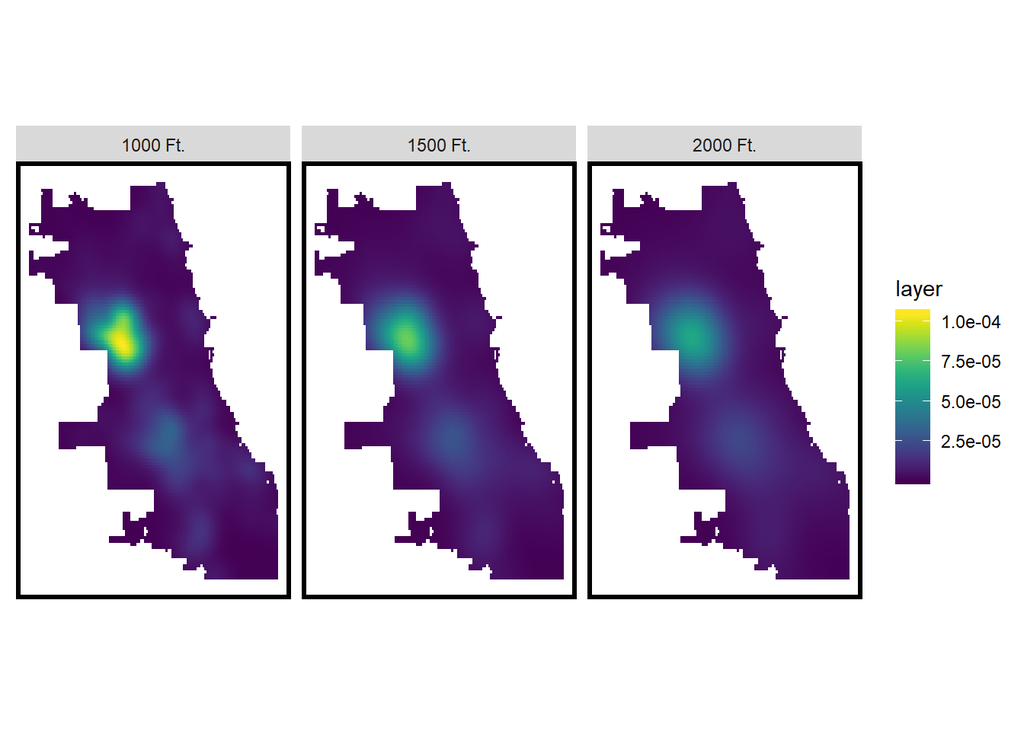

```r
library(raster)
narc_ppp <- as.ppp(st_coordinates(narcotics), W = st_bbox(final_net))
narc_KD.1000 <- spatstat::density.ppp(narc_ppp, 1000)
narc_KD.1500 <- spatstat::density.ppp(narc_ppp, 1500)
narc_KD.2000 <- spatstat::density.ppp(narc_ppp, 2000)
narc_KD.df <- rbind(
  mutate(data.frame(rasterToPoints(mask(raster(narc_KD.1000), as(neighborhoods, 'Spatial')))), Legend = "1000 Ft."),
  mutate(data.frame(rasterToPoints(mask(raster(narc_KD.1500), as(neighborhoods, 'Spatial')))), Legend = "1500 Ft."),
  mutate(data.frame(rasterToPoints(mask(raster(narc_KD.2000), as(neighborhoods, 'Spatial')))), Legend = "2000 Ft."))

narc_KD.df$Legend <- factor(narc_KD.df$Legend, levels = c("1000 Ft.", "1500 Ft.", "2000 Ft."))

ggplot(data=narc_KD.df, aes(x=x, y=y)) +
  geom_raster(aes(fill=layer)) +
  facet_wrap(~Legend) +
  coord_sf(crs=st_crs(final_net)) +
  scale_fill_viridis() +
  mapTheme()
```

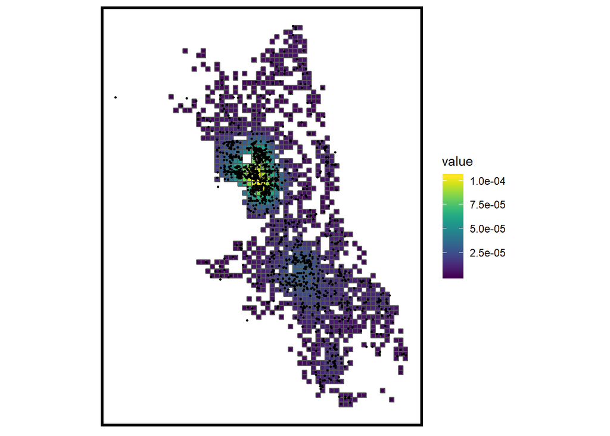

```r
narc_ppp <- as.ppp(st_coordinates(narcotics), W = st_bbox(final_net))
narc_KD <- spatstat::density.ppp(narc_ppp, 1000)

as.data.frame(narc_KD) %>%
  st_as_sf(coords = c("x", "y"), crs = st_crs(final_net)) %>%
  aggregate(., final_net, mean) %>%
  ggplot() +
  geom_sf(aes(fill=value)) +
  geom_sf(data = sample_n(narcotics, 1500), size = .5) +
  scale_fill_viridis() +
  mapTheme()
```

The kernel density map that was generated using 1000 FT distance gave the best outcome in terms of hotspot distinction and clarity. This was then compared with the regression model with LOGO-Cross validation and Spatial Structure. First, both the kernel densities and predicted values were scaled to a scale of 100 and classified into different risk categories. The maps below show the distribution of the risk categories for kernel densities of the observed crimes and the selected regression model. The observed crime locations were overlayed on both maps for comparison..

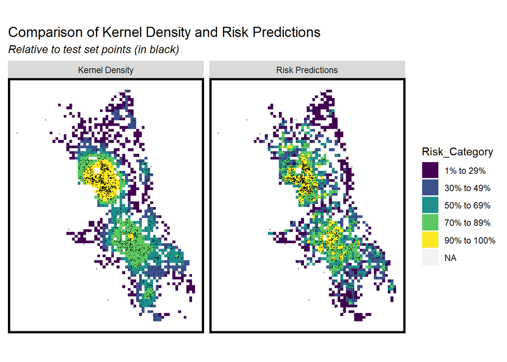

```r
# Compute kernel density
narc_ppp <- as.ppp(st_coordinates(narcotics), W = st_bbox(final_net))
narc_KD <- spatstat::density.ppp(narc_ppp, 1000)
# Convert kernel density to grid cells taking the mean
narc_KDE_sf <- as.data.frame(narc_KD) %>%
  st_as_sf(coords = c("x", "y"), crs = st_crs(final_net)) %>%
  aggregate(., final_net, mean) %>%
  #Mutate the Risk_Category field as defined below.
  mutate(label = "Kernel Density",
         Risk_Category = ntile(value, 100),
         Risk_Category = case_when(
           Risk_Category >= 90 ~ "90% to 100%",
           Risk_Category >= 70 & Risk_Category <= 89 ~ "70% to 89%",
           Risk_Category >= 50 & Risk_Category <= 69 ~ "50% to 69%",
           Risk_Category >= 30 & Risk_Category <= 49 ~ "30% to 49%",
           Risk_Category >= 1 & Risk_Category <= 29 ~ "1% to 29%")) %>%
  #Bind to a layer where test set crime counts are spatially joined to the fisnnet.
  bind_cols(
    aggregate(
      dplyr::select(narcotics) %>% mutate(narcCount = 1), ., length) %>%
      mutate(narcCount = replace_na(narcCount, 0))) %>%
  #Select the fields we need
  dplyr::select(label, Risk_Category, narcCount)

narc_risk_sf <-
  filter(final_reg, Regression == "Spatial LOGO-CV: Spatial Structure") %>%
  mutate(label = "Risk Predictions",
         Risk_Category = ntile(Prediction, 100),
         Risk_Category = case_when(
           Risk_Category >= 90 ~ "90% to 100%",
           Risk_Category >= 70 & Risk_Category <= 89 ~ "70% to 89%",
           Risk_Category >= 50 & Risk_Category <= 69 ~ "50% to 69%",
           Risk_Category >= 30 & Risk_Category <= 49 ~ "30% to 49%",
           Risk_Category >= 1 & Risk_Category <= 29 ~ "1% to 29%")) %>%
  bind_cols(
    aggregate(
      dplyr::select(narcotics) %>% mutate(narcCount = 1), ., length) %>%
      mutate(narcCount = replace_na(narcCount, 0))) %>%
  dplyr::select(label,Risk_Category, narcCount)

rbind(narc_KDE_sf, narc_risk_sf) %>%
  gather(Variable, Value, -label, -Risk_Category, -geometry) %>%
  ggplot() +
  geom_sf(aes(fill = Risk_Category), colour = NA) +
  geom_sf(data = sample_n(narcotics, 1500), size = .1, colour = "black") +
  facet_wrap(~label, ) +
  scale_fill_viridis(discrete = TRUE) +
  labs(title="Comparison of Kernel Density and Risk Predictions",
       subtitle="Relative to test set points (in black)") +
  mapTheme()
```

### *Bar plot comparing kernel density to risk predictions*

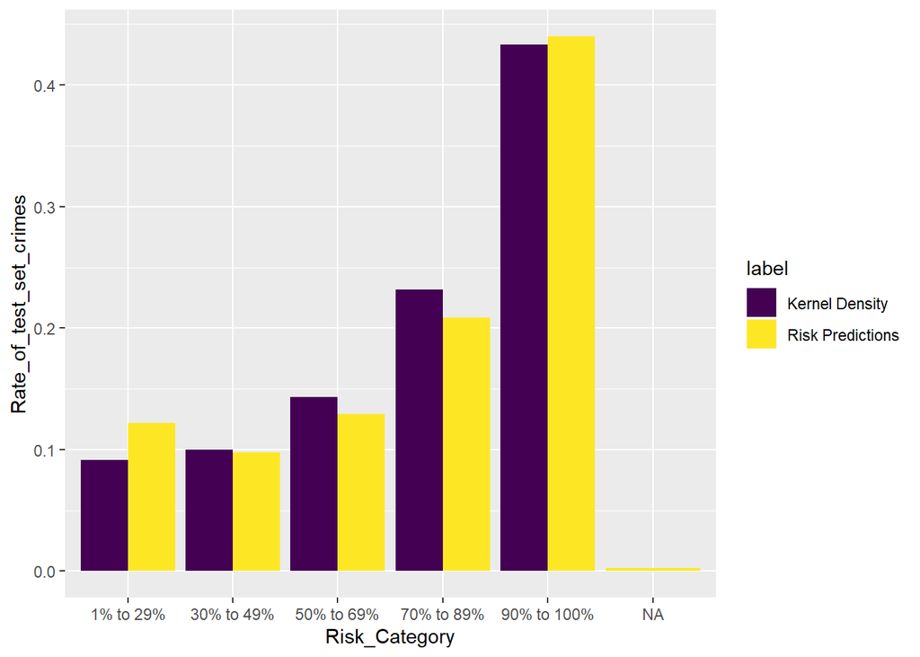

```r
rbind(narc_KDE_sf, narc_risk_sf) %>%
  st_set_geometry(NULL) %>%
  gather(Variable, Value, -label, -Risk_Category) %>%
  group_by(label, Risk_Category) %>%
  summarize(countNarc = sum(Value)) %>%
  ungroup() %>%
  group_by(label) %>%
  mutate(Rate_of_test_set_crimes = countNarc / sum(countNarc)) %>%
  ggplot(aes(Risk_Category,Rate_of_test_set_crimes)) +
  geom_bar(aes(fill=label), position="dodge", stat="identity") +
  scale_fill_viridis(discrete = TRUE)
```

# **Conclusion**

The goal of this project is to create a regression model that predicts crime risk in Chicago without any significant racial bias in the model. The regression model that accounts for the spatial structure of crime gives relatively better results. However, the mean absolute error and its standard deviation for the model is still significant. The use of better or additional predictors may help. This can only be said conclusively after trying out a variety of different predictable variables.

Furthermore, even though the model attempts to remove racial bias, a result of overpolicing of minority neighborhoods, there is still over predicting of crime for non-white neighborhoods and underpredicting of crime in majority white neighborhoods. Given how the model doesn’t entirey achieve its goal, I would not recommend this algorithm to be put into production. It is necessary to further streamline this model since it shows potential to be applied for real time use.